# Data Preparation and Association Rule Mining

#### Reading Employee Attrition Data

```r
library(tidyverse)
emp_atr <- read_csv("employee_attrition.csv", col_types = cols())
attr(emp_atr, 'spec') <- NULL
dim(emp_atr)
```

```
## [1] 1176   35
```

```r
str(emp_atr)
```

```
## Classes 'spec_tbl_df', 'tbl_df', 'tbl' and 'data.frame': 1176 obs. of  35 variables:
##  $ Age                     : num  30 52 42 55 35 51 42 23 38 27 ...
##  $ Attrition               : chr  "No" "No" "No" "No" ...
##  $ BusinessTravel          : chr  "Travel_Rarely" "Travel_Rarely" "Travel_Rarely" "Non-Travel" ...
##  $ DailyRate               : num  1358 1325 462 177 1029 ...
##  $ Department              : chr  "Sales" "Research & Development" "Sales" "Research & Development" ...
##  $ DistanceFromHome        : num  16 11 14 8 16 26 1 20 6 2 ...
##  $ Education               : num  1 4 2 1 3 4 2 1 2 1 ...
##  $ EducationField          : chr  "Life Sciences" "Life Sciences" "Medical" "Medical" ...
##  $ EmployeeCount           : num  1 1 1 1 1 1 1 1 1 1 ...
##  $ EmployeeNumber          : num  1479 813 936 1278 1529 ...
##  $ EnvironmentSatisfaction : num  4 4 3 4 4 1 4 1 4 3 ...
##  $ Gender                  : chr  "Male" "Female" "Female" "Male" ...
##  $ HourlyRate              : num  96 82 68 37 91 66 43 97 40 85 ...
##  $ JobInvolvement          : num  3 3 2 2 2 3 2 3 2 3 ...
```

[output cut: 21 more lines]

#### Preview of Data

```r
library(knitr)
knitr::kable(head(emp_atr))
```

| Age | Attrition | BusinessTravel | DailyRate | Department | DistanceFromHome | Education | EducationField | EmployeeCount | EmployeeNumber | EnvironmentSatisfaction | Gender | HourlyRate | JobInvolvement | JobLevel | JobRole | JobSatisfaction | MaritalStatus | MonthlyIncome | MonthlyRate | NumCompaniesWorked | Over18 | OverTime | PercentSalaryHike | PerformanceRating | RelationshipSatisfaction | StandardHours | StockOptionLevel | TotalWorkingYears | TrainingTimesLastYear | … |
| --- | --- | --- | --- | --- | --- | --- | --- | --- | --- | --- | --- | --- | --- | --- | --- | --- | --- | --- | --- | --- | --- | --- | --- | --- | --- | --- | --- | --- | --- | --- |
| 30 | No | Travel_Rarely | 1358 | Sales | 16 | 1 | Life Sciences | 1 | 1479 | 4 | Male | 96 | 3 | 2 | Sales Executive | 3 | Married | 5301 | 2939 | 8 | Y | No | 15 | 3 | 3 | 80 | 2 | 4 | 2 | … |
| 52 | No | Travel_Rarely | 1325 | Research & Development | 11 | 4 | Life Sciences | 1 | 813 | 4 | Female | 82 | 3 | 2 | Laboratory Technician | 3 | Married | 3149 | 21821 | 8 | Y | No | 20 | 4 | 2 | 80 | 1 | 9 | 3 | … |
| 42 | No | Travel_Rarely | 462 | Sales | 14 | 2 | Medical | 1 | 936 | 3 | Female | 68 | 2 | 2 | Sales Executive | 3 | Single | 6244 | 7824 | 7 | Y | No | 17 | 3 | 1 | 80 | 0 | 10 | 6 | … |
| 55 | No | Non-Travel | 177 | Research & Development | 8 | 1 | Medical | 1 | 1278 | 4 | Male | 37 | 2 | 4 | Healthcare Representative | 2 | Divorced | 13577 | 25592 | 1 | Y | Yes | 15 | 3 | 4 | 80 | 1 | 34 | 3 | … |
| 35 | No | Travel_Rarely | 1029 | Research & Development | 16 | 3 | Life Sciences | 1 | 1529 | 4 | Female | 91 | 2 | 3 | Healthcare Representative | 2 | Single | 8606 | 21195 | 1 | Y | No | 19 | 3 | 4 | 80 | 0 | 11 | 3 | … |
| 51 | No | Travel_Rarely | 1318 | Sales | 26 | 4 | Marketing | 1 | 851 | 1 | Female | 66 | 3 | 4 | Manager | 3 | Married | 16307 | 5594 | 2 | Y | No | 14 | 3 | 3 | 80 | 1 | 29 | 2 | … |

Removing those attributes that are not useful for the analysis

```r
emp_atr <- select(emp_atr, -c("EmployeeCount", "EmployeeNumber", "Over18", "StandardHours"))
```

#### Changing Attribute Type

Converting character type to factor

```r
char_var <- sapply(emp_atr, is.character)
emp_atr[,char_var] <- lapply(emp_atr[,char_var], as.factor)
```

### Data Quality Issues

#### 1. Data outliers

Looking for outliers by plotting a boxplot

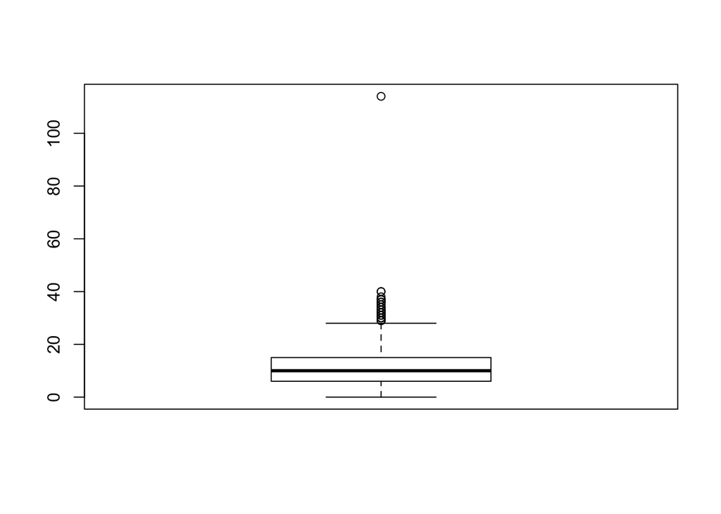

```r
boxplot(emp_atr$TotalWorkingYears)
```

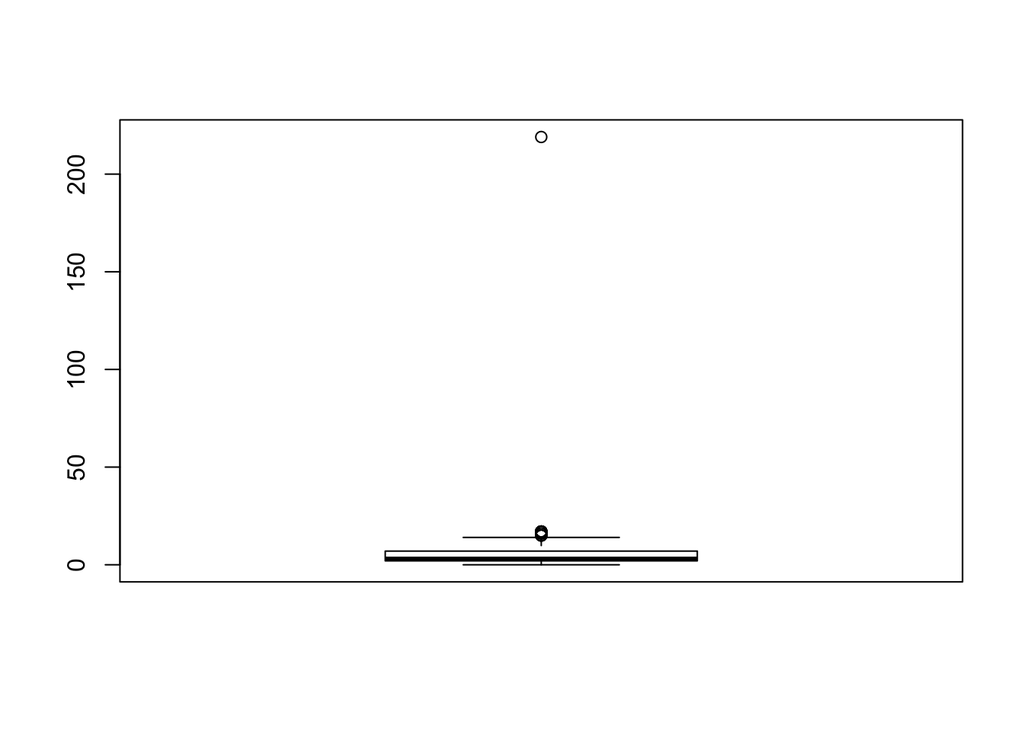

```r
boxplot(emp_atr$YearsWithCurrManager)
```

Omitting the extreme outliers in total working years and years with current manager as the values are much higher than corresponding employee age

```r
outlier_obs <- c(which(emp_atr$TotalWorkingYears == 114), which(emp_atr$YearsWithCurrManager == 219))
emp_atr <- emp_atr[-outlier_obs, ]
```

#### 2. Missing values

Checking for number missing values

```r
sum(is.na(emp_atr))
```

```
## [1] 11
```

Looking for attributes with missing valies

```r
which(apply(emp_atr, 2, function(x) sum(is.na(x))) > 0)
```

```
##         DistanceFromHome                   Gender                 JobLevel
##                        6                       10                       13
##                 OverTime        PercentSalaryHike        PerformanceRating
##                       20                       21                       22
## RelationshipSatisfaction        TotalWorkingYears  YearsSinceLastPromotion
##                       23                       25                       30
```

Replacing missing value with mean of the attribute

```r
emp_atr$DistanceFromHome[is.na(emp_atr$DistanceFromHome)] <- mean(emp_atr$DistanceFromHome, na.rm = T)
emp_atr$JobLevel[is.na(emp_atr$JobLevel)] <- mean(emp_atr$JobLevel, na.rm = T)
emp_atr$PercentSalaryHike[is.na(emp_atr$PercentSalaryHike)] <- mean(emp_atr$PercentSalaryHike, na.rm = T)
emp_atr$PerformanceRating[is.na(emp_atr$PerformanceRating)] <- mean(emp_atr$PerformanceRating, na.rm = T)
emp_atr$RelationshipSatisfaction[is.na(emp_atr$RelationshipSatisfaction)] <- mean(emp_atr$RelationshipSatisfaction, na.rm = T)
emp_atr$TotalWorkingYears[is.na(emp_atr$TotalWorkingYears)] <- mean(emp_atr$TotalWorkingYears, na.rm = T)
emp_atr$YearsSinceLastPromotion[is.na(emp_atr$YearsSinceLastPromotion)] <- mean(emp_atr$YearsSinceLastPromotion, na.rm = T)
```

Since both Gender and OverTime are of type factor, it is better to omit the observations with missing values for further analysis

```r
emp_atr <- emp_atr[-c(which(is.na(emp_atr$Gender)), which(is.na(emp_atr$OverTime))),]
ea <- emp_atr
```

#### 3. Duplicate records

Counting number of duplicate records in the data

```r
nrow(emp_atr[duplicated(emp_atr), ])
```

```
## [1] 0
```

### Exploratory Data Analysis

Comparing employee rate and income based on different education field

```r
library(dplyr)
kable(emp_atr %>% group_by(EducationField) %>%
  summarise(TotalEmployees = n(), DailyRate = round(mean(DailyRate, na.rm = T)),
            HourlyRate = round(mean(HourlyRate, na.rm = T)),
            MonthlyIncome = round(mean(MonthlyIncome, na.rm = T)),
            MonthlyRate = round(mean(MonthlyRate, na.rm = T)),
            PercentSalaryHike = round(mean(PercentSalaryHike, na.rm = T))) %>%
  arrange(desc(TotalEmployees)))
```

| EducationField | TotalEmployees | DailyRate | HourlyRate | MonthlyIncome | MonthlyRate | PercentSalaryHike |
| --- | --- | --- | --- | --- | --- | --- |
| Life Sciences | 475 | 808 | 66 | 6440 | 14662 | 15 |
| Medical | 379 | 821 | 66 | 6542 | 14237 | 15 |
| Marketing | 127 | 710 | 66 | 7275 | 14309 | 15 |
| Technical Degree | 97 | 849 | 69 | 5734 | 14758 | 15 |
| Other | 69 | 797 | 62 | 5939 | 14027 | 16 |
| Human Resources | 25 | 654 | 59 | 7460 | 14879 | 15 |

Comparing employee rate and income in each department based on gender

```r
kable(emp_atr %>% group_by(Department, Gender) %>%
  summarise(TotalEmployees = n(), DailyRate = round(mean(DailyRate, na.rm = T)),
            HourlyRate = round(mean(HourlyRate, na.rm = T)),
            MonthlyIncome = round(mean(MonthlyIncome, na.rm =T)),
            PercentSalaryHike = round(mean(PercentSalaryHike, na.rm = T))))
```

| Department | Gender | TotalEmployees | DailyRate | HourlyRate | MonthlyIncome | PercentSalaryHike |
| --- | --- | --- | --- | --- | --- | --- |
| Human Resources | Female | 18 | 848 | 53 | 7463 | 14 |
| Human Resources | Male | 36 | 678 | 68 | 6352 | 15 |
| Research & Development | Female | 309 | 779 | 65 | 6530 | 15 |
| Research & Development | Male | 453 | 823 | 67 | 6131 | 16 |
| Sales | Female | 155 | 838 | 67 | 6833 | 15 |
| Sales | Male | 201 | 775 | 64 | 6952 | 15 |

Comparing employees with different job role based on monthly income and percentage hike in salary

```r
kable(emp_atr %>% group_by(JobRole) %>%
  summarise(TotalEmployees = n(), MonthlyIncome = round(mean(MonthlyIncome, na.rm =T)),
            PercentSalaryHike = round(mean(PercentSalaryHike, na.rm = T))) %>%
  arrange(desc(TotalEmployees)))
```

| JobRole | TotalEmployees | MonthlyIncome | PercentSalaryHike |
| --- | --- | --- | --- |
| Sales Executive | 261 | 6905 | 15 |
| Research Scientist | 220 | 3174 | 16 |
| Laboratory Technician | 209 | 3330 | 15 |
| Manufacturing Director | 122 | 7175 | 15 |
| Healthcare Representative | 108 | 7594 | 15 |
| Manager | 78 | 17385 | 15 |
| Sales Representative | 67 | 2612 | 16 |
| Research Director | 64 | 16054 | 15 |
| Human Resources | 43 | 3815 | 15 |

Determining employee attrition based on gender

```r
kable(emp_atr %>% group_by(Gender, Attrition) %>%
  summarise(TotalEmployees = n()))
```

| Gender | Attrition | TotalEmployees |
| --- | --- | --- |
| Female | No | 412 |
| Female | Yes | 70 |
| Male | No | 575 |
| Male | Yes | 115 |

Determining employee attrition based on job role

```r
kable(emp_atr %>% group_by(JobRole, Attrition) %>%
  summarise(TotalEmployees = n()))
```

| JobRole | Attrition | TotalEmployees |
| --- | --- | --- |
| Healthcare Representative | No | 101 |
| Healthcare Representative | Yes | 7 |
| Human Resources | No | 33 |
| Human Resources | Yes | 10 |
| Laboratory Technician | No | 162 |
| Laboratory Technician | Yes | 47 |
| Manager | No | 75 |
| Manager | Yes | 3 |
| Manufacturing Director | No | 114 |
| Manufacturing Director | Yes | 8 |
| Research Director | No | 62 |
| Research Director | Yes | 2 |
| Research Scientist | No | 188 |
| Research Scientist | Yes | 32 |
| Sales Executive | No | 213 |
| Sales Executive | Yes | 48 |
| Sales Representative | No | 39 |
| Sales Representative | Yes | 28 |

Determining employee attrition based on working overtime

```r
kable(emp_atr %>% group_by(OverTime, Attrition) %>%
  summarise(TotalEmployees = n()))
```

| OverTime | Attrition | TotalEmployees |
| --- | --- | --- |
| No | No | 745 |
| No | Yes | 91 |
| Yes | No | 242 |
| Yes | Yes | 94 |

### Dimension Reduction

Determining correlation between different attributes

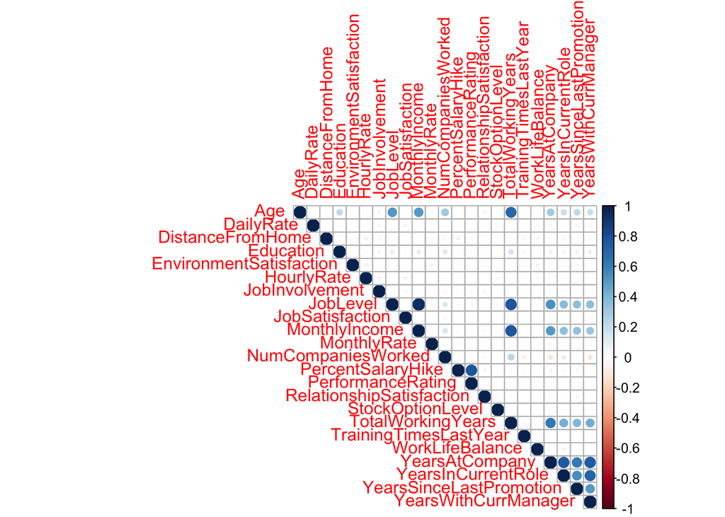

```r
library(corrplot)
cor_matrix <- cor(emp_atr[complete.cases(emp_atr), sapply(emp_atr, is.numeric)], method = "pearson")
corrplot(cor_matrix, type = "upper")
```

```r
emp_atr <- select(emp_atr, -c("Education", "DailyRate", "DistanceFromHome", "EnvironmentSatisfaction", "HourlyRate",
                              "JobInvolvement", "JobSatisfaction", "MonthlyRate", "NumCompaniesWorked",
                              "PercentSalaryHike", "PerformanceRating", "RelationshipSatisfaction", "StockOptionLevel",
                              "TrainingTimesLastYear", "WorkLifeBalance"))
```

### Discretization

Converting numerical attributes to categorical as Association Rule Mining works only with categorical variables

```r
library(arules)
library(arulesViz)
emp_atr$Age <- arules::discretize(emp_atr$Age, method = "fixed",
                            breaks = c(18, 30, 45, 60), labels = c("Below 30", "Between 30 and 45", "Above 45"))
emp_atr$JobLevel <- arules::discretize(emp_atr$JobLevel, method = "interval",
                            breaks = 5, labels = c("1", "2", "3", "4", "5"))
emp_atr$MonthlyIncome <- arules::discretize(emp_atr$MonthlyIncome, method = "fixed",
                            breaks = c(0,5000, 10000, 15000, 20000), labels = c("Less than 5000", "Between 5000 and 10000",
                            "Between 10000 and 15000", "Above 15000"))
emp_atr$TotalWorkingYears <- arules::discretize(emp_atr$TotalWorkingYears, method = "interval",
                            breaks = 3, labels = c("Less", "Medium", "High"))
emp_atr$YearsAtCompany <- arules::discretize(emp_atr$YearsAtCompany, method = "interval",
                            breaks = 3, labels = c("Less", "Medium", "High"))
emp_atr$YearsInCurrentRole <- arules::discretize(emp_atr$YearsInCurrentRole, method = "interval",
                            breaks = 3, labels = c("Less", "Medium", "High"))
```

### Visualization

#### Department vs Attritiom

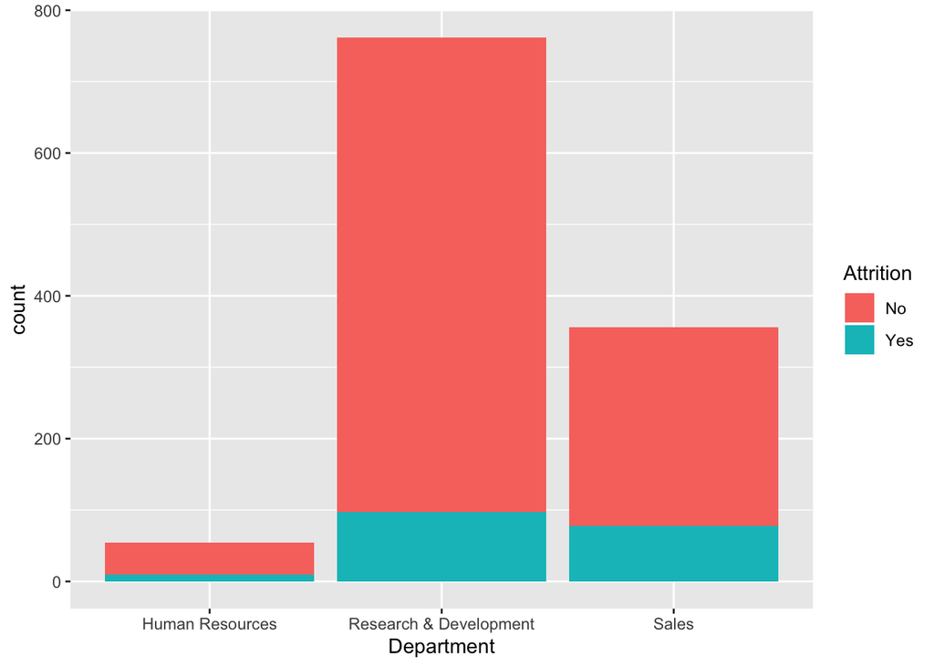

```r
library(ggplot2)
ggplot(ea, aes(x = Department, fill = Attrition)) +
  geom_bar()
```

Most of the employees who leave the company belong to Research and Development department

#### MonthlyIncome vs Attrition

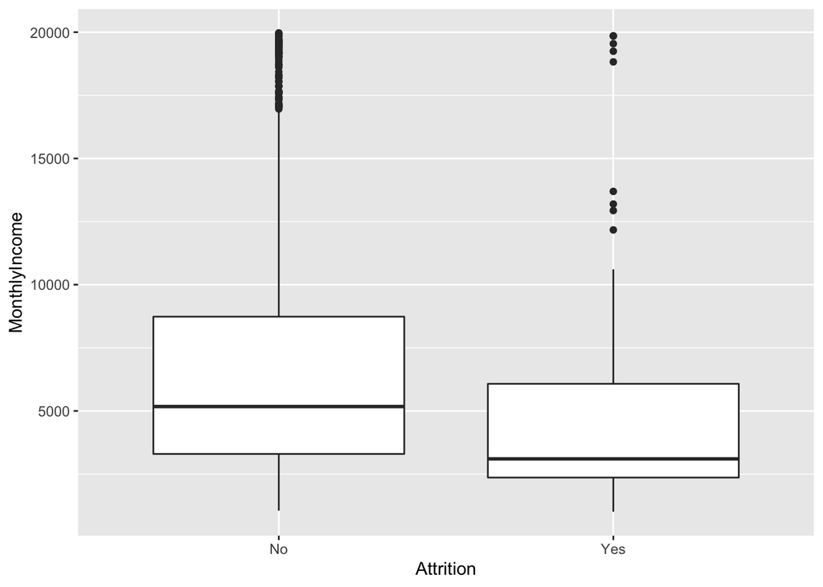

```r
ggplot(ea, aes(x = Attrition, y = MonthlyIncome)) +
  geom_boxplot()
```

Employees with less monthly income choose to leave the company

#### MonthlyIncome vs YearsInCurrentRole

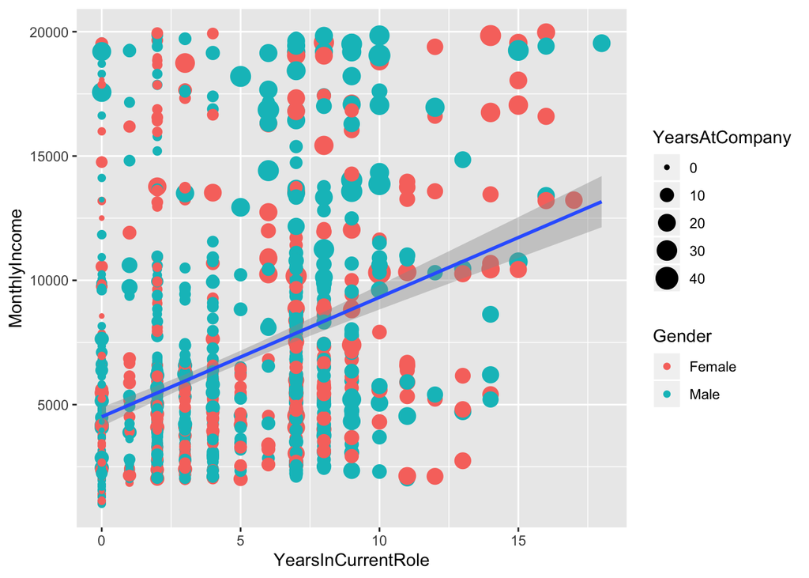

```r
ggplot(ea,aes(x = YearsInCurrentRole, y = MonthlyIncome)) +
  geom_point(aes(color = Gender, size = YearsAtCompany)) +
  geom_smooth(method = "lm")
```

#### JobLevel density and Attrition

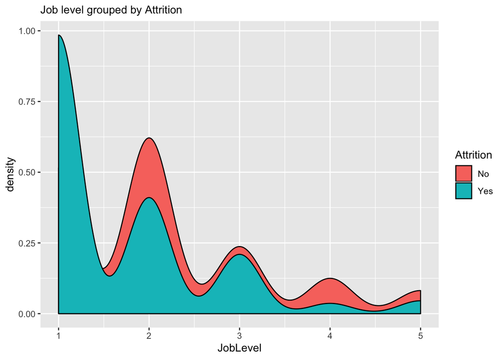

```r
ggplot(ea, aes(JobLevel)) +
  geom_density(aes(fill = Attrition)) +
    labs(subtitle = "Job level grouped by Attrition", x="JobLevel",fill="Attrition")
```

Employees at lower job levels leave the company more often than the employees at higher level

### Association Rule Mining

#### Baseline model

Generating transcational dataset from record dataset

```r
fac_var <- sapply(emp_atr, is.factor)
employee <- as(emp_atr[, fac_var], "transactions")
inspect(head(employee, 2))
```

```
##     items                                  transactionID
## [1] {Age=Between 30 and 45,
##      Attrition=No,
##      BusinessTravel=Travel_Rarely,
##      Department=Sales,
##      EducationField=Life Sciences,
##      Gender=Male,
##      JobLevel=2,
##      JobRole=Sales Executive,
##      MaritalStatus=Married,
##      MonthlyIncome=Between 5000 and 10000,
##      OverTime=No,
##      TotalWorkingYears=Less,
##      YearsAtCompany=Less,
##      YearsInCurrentRole=Less}                          1
## [2] {Age=Above 45,
##      Attrition=No,
##      BusinessTravel=Travel_Rarely,
##      Department=Research & Development,
##      EducationField=Life Sciences,
##      Gender=Female,
##      JobLevel=2,
##      JobRole=Laboratory Technician,
##      MaritalStatus=Married,
##      MonthlyIncome=Less than 5000,
##      OverTime=No,
##      TotalWorkingYears=Less,
##      YearsAtCompany=Less,
##      YearsInCurrentRole=Less}                          2
```

Running Apriori on transactional dataset with default values

```r
rules_transaction <- apriori(employee)
```

```r
inspect(head(rules_transaction, 5))
```

```
##     lhs                                 rhs                                   support confidence     lift count
## [1] {}                               => {Attrition=No}                      0.8421502  0.8421502 1.000000   987
## [2] {}                               => {YearsAtCompany=Less}               0.8856655  0.8856655 1.000000  1038
## [3] {JobRole=Manufacturing Director} => {Department=Research & Development} 0.1040956  1.0000000 1.538058   122
## [4] {EducationField=Marketing}       => {Department=Sales}                  0.1083618  1.0000000 3.292135   127
## [5] {JobLevel=3}                     => {Attrition=No}                      0.1262799  0.8654971 1.027723   148
```

Fine tuning the baseline model by assigning support and confidence values

```r
rules_transaction <- apriori(employee, parameter = list(support = 0.01, confidence = 0.3, minlen = 3))
```

```r
inspect(head(rules_transaction, 5))
```

```
##     lhs                            rhs                            support confidence      lift count
## [1] {TotalWorkingYears=High,
##      YearsAtCompany=High}       => {Age=Above 45}              0.01450512  1.0000000  4.764228    17
## [2] {Age=Above 45,
##      YearsAtCompany=High}       => {TotalWorkingYears=High}    0.01450512  1.0000000 16.985507    17
## [3] {TotalWorkingYears=High,
##      YearsAtCompany=High}       => {YearsInCurrentRole=Medium} 0.01109215  0.7647059  2.442058    13
## [4] {YearsAtCompany=High,
##      YearsInCurrentRole=Medium} => {TotalWorkingYears=High}    0.01109215  1.0000000 16.985507    13
## [5] {TotalWorkingYears=High,
##      YearsInCurrentRole=Medium} => {YearsAtCompany=High}       0.01109215  0.4062500 28.007353    13
```

- Very low value of support will simply include the rules that occoures by chance
- Low confidence imples the inference made by the rule is not very reliable
- Having low value of both support and confidence will lead to overfitting and produce a lot more rules than necessary

Increasing the value of support and confidence and running the model

```r
rules_transaction <- apriori(employee, parameter = list(support = 0.5, confidence = 0.95, minlen = 3))
```

```r
inspect(head(rules_transaction, 5))
```

```
##     lhs                               rhs                     support confidence     lift count
## [1] {TotalWorkingYears=Less,
##      YearsInCurrentRole=Less}      => {YearsAtCompany=Less} 0.5298635  1.0000000 1.129094   621
## [2] {Attrition=No,
##      YearsInCurrentRole=Less}      => {YearsAtCompany=Less} 0.5221843  0.9855072 1.112731   612
## [3] {OverTime=No,
##      TotalWorkingYears=Less}       => {YearsAtCompany=Less} 0.5153584  0.9983471 1.127228   604
## [4] {BusinessTravel=Travel_Rarely,
##      TotalWorkingYears=Less}       => {YearsAtCompany=Less} 0.5034130  1.0000000 1.129094   590
## [5] {Attrition=No,
##      TotalWorkingYears=Less}       => {YearsAtCompany=Less} 0.5827645  1.0000000 1.129094   683
```

- We might miss out on some interesting rules if the value of support if very high
- Having very high confidence will lead to underfitting ang generate fever rules than expected
- Fine tuning the model with appropriate value of support and confidence is very essential in order to capture significant rules whose inference can be reliable

Setting support to 0.1, confidence to 0.85 and inspecting the rules

```r
rules_transaction <- apriori(employee, parameter = list(support = 0.1, confidence = 0.85, minlen = 3))
```

```r
inspect(head(rules_transaction, 5))
```

```
##     lhs                               rhs                         support confidence     lift count
## [1] {Attrition=Yes,
##      MonthlyIncome=Less than 5000} => {TotalWorkingYears=Less}  0.1006826  0.9365079 1.309770   118
## [2] {Attrition=Yes,
##      MonthlyIncome=Less than 5000} => {YearsAtCompany=Less}     0.1066553  0.9920635 1.120133   125
## [3] {Attrition=Yes,
##      YearsInCurrentRole=Less}      => {TotalWorkingYears=Less}  0.1134812  0.9047619 1.265371   133
## [4] {Attrition=Yes,
##      TotalWorkingYears=Less}       => {YearsInCurrentRole=Less} 0.1134812  0.8580645 1.309442   133
## [5] {Attrition=Yes,
##      YearsInCurrentRole=Less}      => {YearsAtCompany=Less}     0.1237201  0.9863946 1.113733   145
```

#### Predicting Attrition

##### 1. Attrition = Yes

```r
rules1 <- apriori(data = employee, parameter = list(supp = 0.01, conf = 0.5, minlen = 3),
                 appearance = list(default = "lhs", rhs = "Attrition=Yes"),
                 control = list(verbose = F))
```

Removing redundant rules

```r
subset_rules <- which(colSums(is.subset(rules1, rules1)) > 1)
rules1 <- sort(rules1[-subset_rules], by = "lift", descreasing = T)
```

Top 5 rules for employees leaving the company

```r
inspect(head(rules1, 5))
```

```
##     lhs                                   rhs                support confidence     lift count
## [1] {EducationField=Marketing,
##      MaritalStatus=Single,
##      OverTime=Yes}                     => {Attrition=Yes} 0.01023891  0.8571429 5.430116    12
## [2] {BusinessTravel=Travel_Frequently,
##      Department=Sales,
##      JobLevel=1}                       => {Attrition=Yes} 0.01279863  0.7500000 4.751351    15
## [3] {Department=Sales,
##      JobLevel=1,
##      OverTime=Yes}                     => {Attrition=Yes} 0.01109215  0.7222222 4.575375    13
## [4] {BusinessTravel=Travel_Frequently,
##      JobRole=Sales Representative}     => {Attrition=Yes} 0.01279863  0.7142857 4.525097    15
## [5] {Department=Sales,
##      MaritalStatus=Single,
##      OverTime=Yes}                     => {Attrition=Yes} 0.02303754  0.7105263 4.501280    27
```

- From the top five rules it is evident that employees who often work overtime in sales department tend to leave the company
- These rules are significant as they have high lift and confidence
- Interesting rules are the ones in which single employees choose to leave the company

Plot for rules with Attrition=Yes

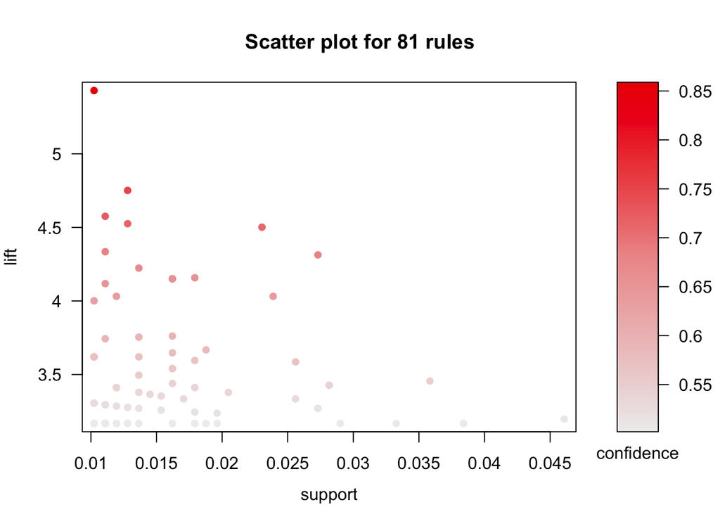

```r
plot(rules1, measure = c("support", "lift"), shading = "confidence", jitter = 0)
```

##### 2. Attrition = No

```r
rules2 <- apriori(data = employee, parameter = list(supp = 0.1, conf = 0.5, minlen = 3),
                 appearance = list(default = "lhs", rhs = "Attrition=No"),
                 control = list(verbose = F))
```

Removing redundant rules

```r
subset_rules <- which(colSums(is.subset(rules2, rules2)) > 1)
rules2 <- sort(rules2[-subset_rules], by = "lift", descreasing = T)
```

Top 5 rules for employees staying with the company

```r
inspect(head(rules2, 5))
```

```
##     lhs                                       rhs              support confidence     lift count
## [1] {Department=Research & Development,
##      MonthlyIncome=Between 5000 and 10000} => {Attrition=No} 0.1433447  0.9491525 1.127059   168
## [2] {OverTime=No,
##      TotalWorkingYears=Medium}             => {Attrition=No} 0.1493174  0.9408602 1.117212   175
## [3] {Department=Research & Development,
##      JobLevel=2}                           => {Attrition=No} 0.1825939  0.9385965 1.114524   214
## [4] {OverTime=No,
##      YearsInCurrentRole=Medium}            => {Attrition=No} 0.2192833  0.9379562 1.113764   257
## [5] {Department=Research & Development,
##      TotalWorkingYears=Medium}             => {Attrition=No} 0.1510239  0.9365079 1.112044   177
```

Plot for rules with Attrition=No

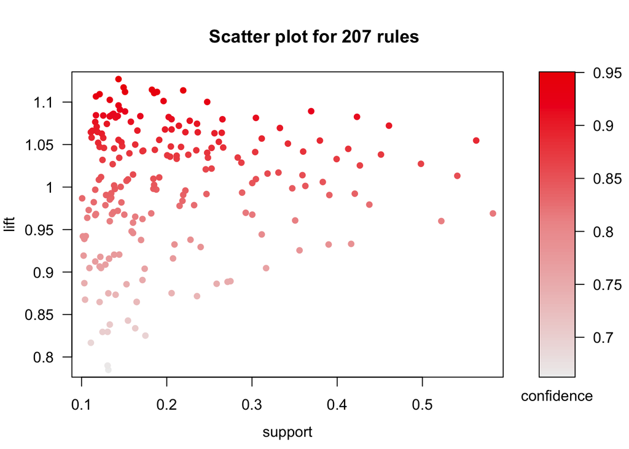

```r
plot(rules2, measure = c("support", "lift"), shading = "confidence", jitter = 0)
```

### Shiny App

Link: [Association Rule Mining](https://nishithavenkatesh.shinyapps.io/associationrule/)